### How can I determine the significance of overlaps?

When genetics datasets are integrated with proteomics data, the overlaps are statistically tested and the results are made available to users. The statistical significance can help to determine, for example, the overlap of interactors and genes genetically linked to a particular disease. Hypergeometric distriubution is used to perform gene list enrichment analysis between experimental proteomics data and 1) user’s uploaded gene list(s) and/or 2) known protein-protein interactions from InWeb. The input file format used in the ‘Integrated Plots’ for genes of interest and InWeb input are identical to those used in ‘Venn Diagrams’ tab.

**Hypergeometric distribution is used to perform gene list enrichment analysis between experimental proteomics data and 1) user’s uploaded gene list(s) and/or 2) known protein-protein interactions from InWeb.**

Using genes of interest as an example, user can adjust FDR, pvalue and logFC sliders to select the values for significance threshold as shown in the figure below.

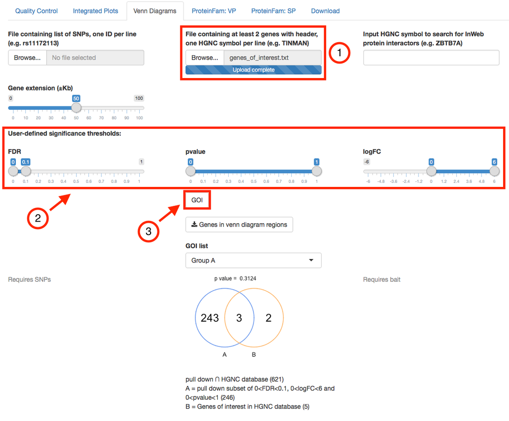

### Different categories of Venn diagam output

**The counts in each field are based on unique gene names.**

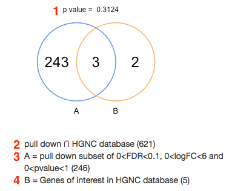

1. **p value**: hypergeometric p-value

2. **population (N)**: subset of gene nomenclatures from proteomics data found in HUGO Gene Nomenclature Committee (guidelines for Human Gene Nomenclature) (total number of genes)

3. **number of success in population (n)**: category A represents proteomics data present in HGNC database that passes the user defined significance threshold (all significant bait interactors)

4. **sample (S)**: user uploaded genes found in HGNC database OR InWeb interactors found in proteomics data

### Multiple lists of genes of interest

If user uploads multiple gene lists, denoted by different columns in one text file, Venn diagram representation and hypergeometric p-value for each list will be generated and calculated. User is able to cycle through the multiple gene lists by clicking on the down arrow and selecting the category name, which corresponds to the column header uploaded by the user.

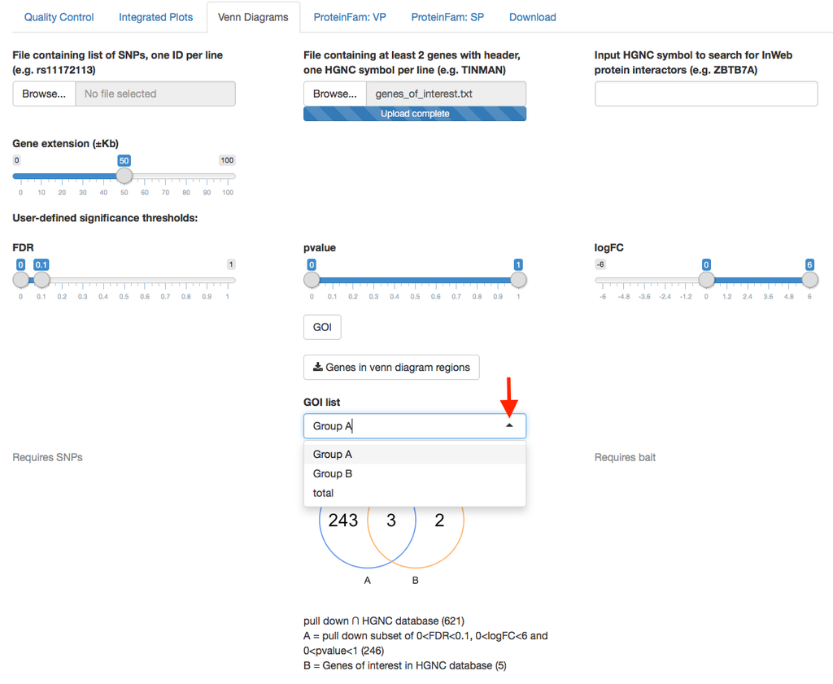